# Unit III

ECON 3406

Dr. Josh Martin

## Differences of two proportions

## Differences of Two Proportions

- Like with $\hat{p}$, the difference of two sample proportions $\hat{p}_1 - \hat{p}_2$ can be modeled using a normal distribution (when conditions are met).

$SE = \sqrt{\dfrac{p_1 (1-p_1)}{n_1} + \dfrac{p_2 (1-p_2)}{n_2}}$

- This standard error comes from the fact that variances of independent variables **add**, even when subtracting.

## Differences of Two Proportions: Standard Errors

- When we talk about the spread of an estimate, we’re really talking about **variance** (the square of the standard error).
- If two random variables **A** and **B** are independent, then:

$\text{Var}(A - B) = \text{Var}(A) + \text{Var}(B)$

- This might seem counterintuitive — but remember:
  - Even if you’re subtracting two noisy measurements, the **uncertainty (noise)** from both still adds up.
  - Think of it like using two shaky rulers. Subtracting doesn’t cancel the shakiness — it just combines it!

## Differences of Two Proportions: Simulation Setup

We’ll use simulation to understand the sampling distribution of sample proportions for two independent groups.

- Group 1 has a true proportion $p_1 = 0.5$
- Group 2 has a true proportion $p_2 = 0.4$
- Each group has $n = 500$ individuals per sample
- We’ll repeat this sampling 1,000 times to observe variation in sample means

## Differences of Two Proportions: Simulation

```r
set.seed(1)       # ensures reproducibility
B <- 1000          # number of simulations
n <- 500           # sample size per group
p1 <- 0.5          # true proportion in group 1
p2 <- 0.4          # true proportion in group 2

# Create empty vectors to store simulated means and SDs
mean_x1 <- mean_x2 <- numeric(B)
sd_x1 <- sd_x2 <- numeric(B)

# Loop to simulate samples for both groups
for (i in 1:B) {
  # Generate random binary outcomes for group 1 (success = 1, failure = 0)
  x1 <- rbinom(n, size = 1, prob = p1)
  mean_x1[i] <- mean(x1)  # sample proportion for group 1
  sd_x1[i]   <- sd(x1)    # sample SD for group 1

  # Repeat for group 2
  x2 <- rbinom(n, size = 1, prob = p2)
  mean_x2[i] <- mean(x2)
  sd_x2[i]   <- sd(x2)
}
```

## Comparing Theoretical and Empirical Standard Errors

- We can compare:
  - the **theoretical** standard error (from the formula)
  - the **empirical** standard error (from our simulations)

## Comparing Theoretical and Empirical Standard Errors

```r
# Theoretical standard error for a sample proportion
sqrt(p1*(1-p1)/n)
```

```
[1] 0.02236068
```

```r
# Empirical standard error from simulated data
mean(sd_x1) / sqrt(n)
```

```
[1] 0.0223613
```

- The first line gives the theoretical SE: $\sqrt{p(1-p)/n}$
- The second line gives the empirical SE, based on simulated SDs
- These values should be nearly identical, validating the normal approximation for large $n$

## Sampling Distribution for One Group (p1 = 0.5)

- We can visualize the distribution of sample proportions across simulations, and overlay a 95% confidence interval around the true mean.

## Sampling Distribution for One Group (p1 = 0.5)

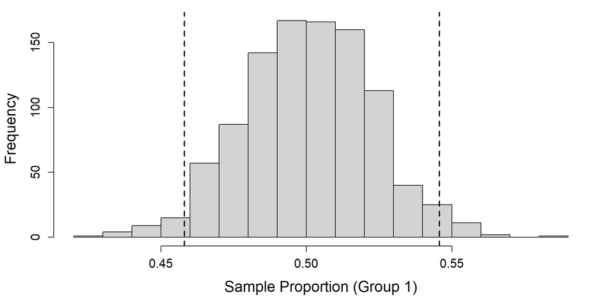

## Sampling Distribution for One Group (p1 = 0.5)

- Roughly 5% of simulated sample proportions should fall outside this interval — confirming the 95% confidence level’s interpretation.

```r
# Calculate the proportion of estimates that fall outside the 95% CI
mean(ifelse(mean_x1 >= ub_x1 | mean_x1 <= lb_x1, 1, 0))
```

```
[1] 0.052
```